# HOMEWORK #1

- Due date: Tuesday, 4/22, at midnight.
- You can get the `.Rmd` of this file [here](http://pages.stat.wisc.edu/%7Egvludwig/327-5/hw1.Rmd)
- What to send: submit your `.Rmd` file only. Make sure it produces any figures and results you need to report correctly.
- Assume the data files are in the same directory, or use the links provided (either choice is fine). Do not point to personal directories.
- Feel free to use and/or modify the `gr.descent()` function implemented in my notes. Note question 3 requires the `optimize()` function, which I will teach next Thursday.
- Note that the robust methods are implemented in the `MASS` package (function `rlm()`) and the exponential smoothing is in the function (`HoltWinters()`). You can check these functions to verify if your code is doing fine **but I will not accept them as solutions to the questions below**. You should code the procedures.
- My solution to the homework is roughly 100 lines long, but some problems are hard. I advise you to start early.

## Q1 : Multicollinearity

Consider the following dataset, a collection of cigarettes with their respective amounts of Tar, Nicotine and Weight:

```r
cigarettes <- read.table("http://pages.stat.wisc.edu/~gvludwig/327-5/cigarettes.dat",
    row.names = 1)
names(cigarettes) <- c("Tar", "Nicotine", "Weight", "CO")
cigarettes
```

```
##                   Tar Nicotine Weight   CO
## Alpine           14.1     0.86 0.9853 13.6
## Benson&Hedges    16.0     1.06 1.0938 16.6
## BullDurham       29.8     2.03 1.1650 23.5
## CamelLights       8.0     0.67 0.9280 10.2
## Carlton           4.1     0.40 0.9462  5.4
## Chesterfield     15.0     1.04 0.8885 15.0
## GoldenLights      8.8     0.76 1.0267  9.0
## Kent             12.4     0.95 0.9225 12.3
## Kool             16.6     1.12 0.9372 16.3
## L&M              14.9     1.02 0.8858 15.4
## LarkLights       13.7     1.01 0.9643 13.0
## Marlboro         15.1     0.90 0.9316 14.4
## Merit             7.8     0.57 0.9705 10.0
## MultiFilter      11.4     0.78 1.1240 10.2
## NewportLights     9.0     0.74 0.8517  9.5
## Now               1.0     0.13 0.7851  1.5
## OldGold          17.0     1.26 0.9186 18.5
## PallMallLight    12.8     1.08 1.0395 12.6
## Raleigh          15.8     0.96 0.9573 17.5
## SalemUltra        4.5     0.42 0.9106  4.9
## Tareyton         14.5     1.01 1.0070 15.9
## True              7.3     0.61 0.9806  8.5
## ViceroyRichLight  8.6     0.69 0.9693 10.6
## VirginiaSlims    15.2     1.02 0.9496 13.9
## WinstonLights    12.0     0.82 1.1184 14.9
```

The source of this dataset is a paper from the [Journal of Statistics Education](http://www.amstat.org/publications/jse/datasets/cigarettes.txt). It illustrates the problem of multicollinearity, namely, when the covariates have a strong linear relationship between themselves, which causes issues in the estimation of Least Squares coefficients (there's a leverage point too, but you can keep it). The response variable is the amount of carbon monoxide in the smoke of the cigarette, in the column `CO` of the dataframe.

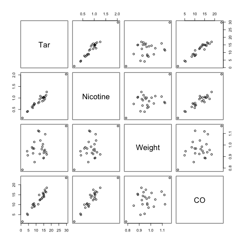

Write down answers for each of the following questions, as well as code pieces whenever necessary:

a. Write R code that calculates the correlations between `CO` and each of the columns `Tar`, `Nicotine` and `Weight`, and show them.

```r
(cor(cigarettes$CO, cigarettes$Tar))
```

```
## [1] 0.9575
```

```r
(cor(cigarettes$CO, cigarettes$Nicotine))
```

```
## [1] 0.9259
```

```r
(cor(cigarettes$CO, cigarettes$Weight))
```

```
## [1] 0.464
```

the results show that the correlation between CO and Tar is really high meaning that they have linear relation. The same about CO and Nicotine. However correlation between CO and Weight is low and means they don't obey each other in linear fashion. It is obeying our expectaions as in plot.

b. Write R code that fits a linear model of `CO` explained by `Tar`, `Nicotine` and `Weight`. Do the coefficients estimated correspond to your expectations? Extract the model matrix from your linear model, and save it in a variable `X`. What can you comment about the form of the `t(X)%*%X` cross product?

```r
fit.model = lm(formula = CO ~ ., data = cigarettes)
summary(fit.model)
```

```
##
## Call:
## lm(formula = CO ~ ., data = cigarettes)
##
## Residuals:
##     Min      1Q  Median      3Q     Max
## -2.8926 -0.7827  0.0043  0.9289  2.4508
##
## Coefficients:
##             Estimate Std. Error t value Pr(>|t|)
## (Intercept)    3.202      3.462    0.93  0.36546
## Tar            0.963      0.242    3.97  0.00069 ***
## Nicotine      -2.632      3.901   -0.67  0.50723
## Weight        -0.130      3.885   -0.03  0.97353
## ---
## Signif. codes:  0 '***' 0.001 '**' 0.01 '*' 0.05 '.' 0.1 ' ' 1
##
## Residual standard error: 1.45 on 21 degrees of freedom
## Multiple R-squared:  0.919,  Adjusted R-squared:  0.907
## F-statistic:   79 on 3 and 21 DF,  p-value: 1.33e-11
```

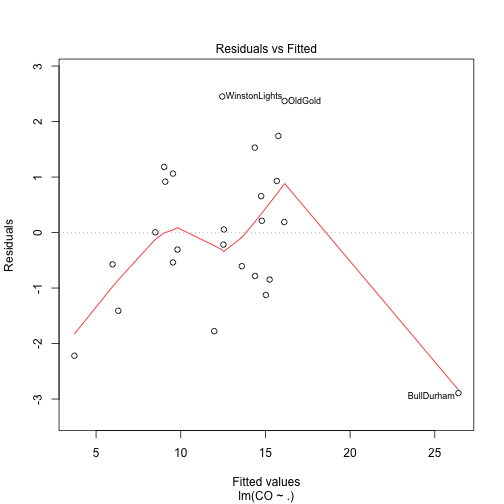

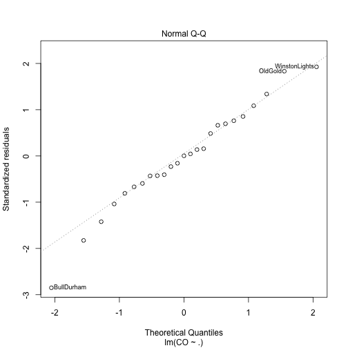

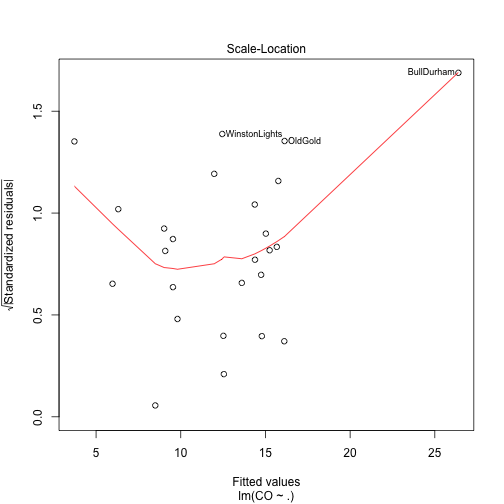

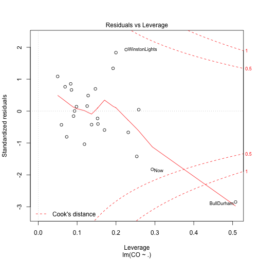

```r
plot(fit.model)
```

```r
X = model.matrix(fit.model)
str(X)
```

```
##  num [1:25, 1:4] 1 1 1 1 1 1 1 1 1 1 ...
##  - attr(*, "dimnames")=List of 2
##   ..$ : chr [1:25] "Alpine" "Benson&Hedges" "BullDurham" "CamelLights" ...
##   ..$ : chr [1:4] "(Intercept)" "Tar" "Nicotine" "Weight"
##  - attr(*, "assign")= int [1:4] 0 1 2 3
```

```r
(result = t(X) %*% X)
```

```
##             (Intercept)    Tar Nicotine Weight
## (Intercept)       25.00  305.4    21.91  24.26
## Tar              305.40 4501.2   314.67 302.18
## Nicotine          21.91  314.7    22.21  21.63
## Weight            24.26  302.2    21.63  23.72
```

```r
(mat.solve = solve(t(X) %*% X))
```

```
##             (Intercept)       Tar Nicotine    Weight
## (Intercept)     5.73351  0.046324  -0.2430 -6.231615
## Tar             0.04632  0.028076  -0.4381 -0.005522
## Nicotine       -0.24301 -0.438092   7.2792 -0.808755
## Weight         -6.23162 -0.005522  -0.8088  7.222484
```

```r
(XbyX <- crossprod(X))
```

```
##             (Intercept)    Tar Nicotine Weight
## (Intercept)       25.00  305.4    21.91  24.26
## Tar              305.40 4501.2   314.67 302.18
## Nicotine          21.91  314.7    22.21  21.63
## Weight            24.26  302.2    21.63  23.72
```

c. Fit a model that explains `CO` by `Tar` and `Weight`. How did the model change? Does your interpretation of the coefficients remain the same?

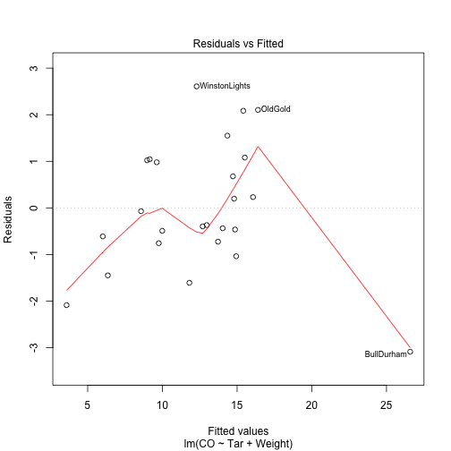

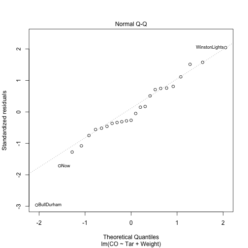

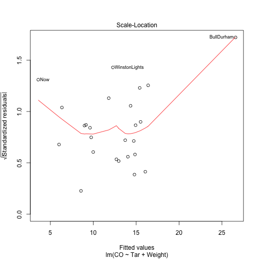

```r
fit.model2 = lm(formula = CO ~ Tar + Weight, data = cigarettes)
plot(fit.model2)
```

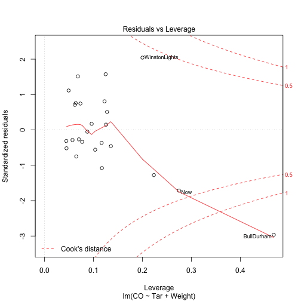

```r
abline(fit.model2)
```

```r
coeffs2 = fit.model2$coefficients
print(coeffs2)
```

```
## (Intercept)         Tar      Weight
##      3.1143      0.8042     -0.4229
```

d. Fit a model that explains `CO` by `Nicotine` and `Weight`. How did the model change? Does your interpretation of the coefficients remain the same?

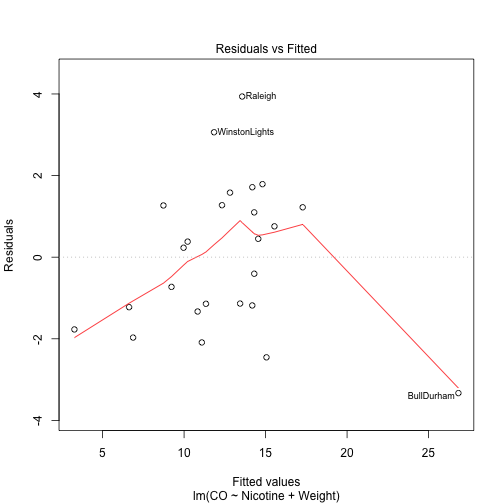

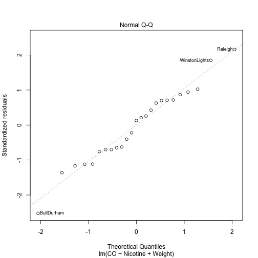

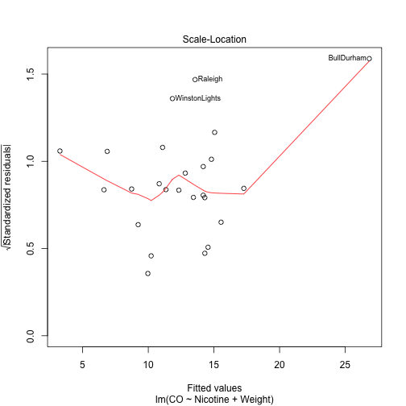

```r
fit.model3 = lm(formula = CO ~ Nicotine + Weight, data = cigarettes)
plot(fit.model3)
```

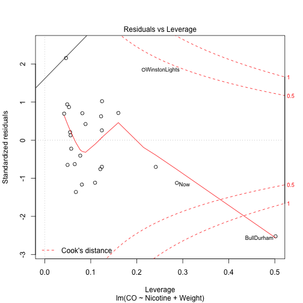

```r
abline(fit.model3)
```

```r
coeffs3 = fit.model3$coefficients
print(coeffs3)
```

```
## (Intercept)    Nicotine      Weight
##     1.61398    12.38812     0.05883
```

## Q2 : Robust Regression

Consider the dataset we constructed in the previous module, which has the Land and Farm area in square miles for all states in the USA.

```r
farmland <- read.csv("http://pages.stat.wisc.edu/~gvludwig/327-5/FarmLandArea.csv")
str(farmland)
```

```
## 'data.frame':    50 obs. of  3 variables:
##  $ state: Factor w/ 50 levels "Alabama","Alaska",..: 1 2 3 4 5 6 7 8 9 10 ...
##  $ land : int  50744 567400 113635 52068 155959 103718 4845 1954 53927 57906 ...
##  $ farm : int  14062 1375 40781 21406 39688 48750 625 766 14453 16094 ...
```

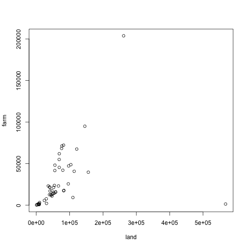

```r
plot(farm ~ land, data = farmland)
```

We want to build a regression model for `farm`, explained by `land`. But we know Alaska is an outlier (and Texas a leverage point). An alternative to fitting a least squares line is to fit a line based on Tukey's \( \rho \) norm, that is, finding the parameters that minimize

\[ MMSE(\beta_0,\beta_1) = \frac{1}{n} \sum_{i=1}^n \rho(y_i - \beta_0 - \beta_1 x_i) \]

where \( \rho(t) \) is given by

\[ \rho(t) = \begin{cases} t^2, & |t| \leq k \\ 2 k |t| - k^2, & |t| > k \end{cases} \]

Note that

\[ \rho\prime(t) = \begin{cases} 2 t, & |t| \leq k \\ 2 k \, \mbox{sign}(t), & |t| > k \end{cases} \]

Which means

\[ \frac{\partial}{\partial \beta_0} MMSE(\beta_0,\beta_1) = - \frac{1}{n} \sum_{i=1}^n \rho\prime (y_i - \beta_0 - \beta_1 x_i) \] \[ \frac{\partial}{\partial \beta_1} MMSE(\beta_0,\beta_1) = - \frac{1}{n} \sum_{i=1}^n x_i \rho\prime (y_i - \beta_0 - \beta_1 x_i) \]

a. Create a scatterplot of `farm` vs. `land`. Include the least squares regression line.

```r
fit = lm(farm ~ land, data = farmland)
abline(fit)  #lease square regression line
```

[output not shown]

[output not shown]

```r
abline(rlm(farm ~ land, data = farmland), col = "red")
```

[output not shown]

b. Fix \( k=19000 \). Estimate \( \beta_0 \), \( \beta_1 \) using gradient descent, for initial value `c(3500,0.33)` (which is really close to the truth). Try a small step size too, say `0.0001`. Does your algorithm converge? Set `verbose=TRUE` to follow the solution.

```r
gr.descent <- function(der_f, x0, alpha = 1e-04, eps = 0.001, max.it = 50, verbose = FALSE) {
    X1 <- x0
    cond <- TRUE
    iteration <- 0
    if (verbose)
        cat("X0 =", X1, "\n")
    while (cond) {
        iteration <- iteration + 1
        X0 <- X1
        X1 <- X0 - alpha * der_f(X0)
        cond <- sum((X1 - X0)^2) > eps & iteration < max.it
        if (verbose)
            cat(paste(sep = "", "X", iteration, " ="), X1, "\n")
    }
    print("mona")
    print(X1)
    return(X1)
}

k = 19000

rho <- function(t, k) ifelse(abs(t) <= k, t^2, (2 * k * abs(t)) - k^2)
rho.prime <- function(t, k) ifelse(abs(t) <= k, 2 * t, (2 * k * sign(t)))

dMMSE <- function(b, k = 19000, y = farmland$farm, x = farmland$land) {

    n = length(y)
    a = 0
    d = 0
    for (i in 1:n) {

        a = a + rho.prime(y[i] - b[1] - b[2] * x[i], k)
        d = d + x[i] * rho.prime(y[i] - b[1] - b[2] * x[i], k)
    }
    a <- (-a/n)
    d <- (-d/n)
    return(c(a, d))
}

grd1 = gr.descent(dMMSE, c(3500, 0.33), alpha = 1e-04, verbose = TRUE)
```

```
## X0 = 3500 0.33
## X1 = 3500 9139
## X2 = 3496 -259467
## X3 = 3500 9139
## X4 = 3496 -259467
## X5 = 3500 9139
## X6 = 3496 -259467
## X7 = 3500 9139
## X8 = 3496 -259467
## X9 = 3500 9139
## X10 = 3496 -259467
## X11 = 3500 9139
## X12 = 3496 -259467
## X13 = 3500 9139
## X14 = 3496 -259467
## X15 = 3500 9139
## X16 = 3496 -259467
## X17 = 3500 9139
## X18 = 3496 -259467
## X19 = 3500 9139
## X20 = 3496 -259467
## X21 = 3500 9139
## X22 = 3496 -259467
## X23 = 3500 9139
## X24 = 3496 -259467
## X25 = 3500 9139
## X26 = 3496 -259467
## X27 = 3500 9139
## X28 = 3496 -259467
## X29 = 3500 9139
## X30 = 3496 -259467
## X31 = 3500 9139
## X32 = 3496 -259467
## X33 = 3500 9139
## X34 = 3496 -259467
## X35 = 3500 9139
## X36 = 3496 -259467
## X37 = 3500 9139
## X38 = 3496 -259467
## X39 = 3500 9139
## X40 = 3496 -259467
## X41 = 3500 9139
## X42 = 3496 -259467
## X43 = 3500 9139
## X44 = 3496 -259467
## X45 = 3500 9139
## X46 = 3496 -259467
## X47 = 3500 9139
## X48 = 3496 -259467
## X49 = 3500 9139
## X50 = 3496 -259467
## [1] "mona"
## [1]    3496 -259467
```

```r
(beta0 = grd1[1])
```

```
## [1] 3496
```

```r
(beta1 = grd1[2])
```

```
## [1] -259467
```

cWe see that it doesn't converge and switches values between numbers.. Modify your gradient descent algorithm so at each step, the parameter \( \alpha \) decreases by half, i.e. \( \alpha_k = \alpha_{k-1}/2 \). Use \( \alpha_1 = 0.1 \). Does your algorithm converge now? What happens if you use the least squares estimates for your initial values, instead of the values `c(3500,0.33)`?

```r
gr.descent2 <- function(der_f, x0, alpha = 0.1, eps = 0.001, max.it = 50, verbose = FALSE) {
    X1 <- x0
    cond <- TRUE
    iteration <- 0
    if (verbose)
        cat("X0 =", X1, "\n")
    while (cond) {
        iteration <- iteration + 1
        X0 <- X1
        X1 <- X0 - alpha * der_f(X0)
        alpha <- alpha/2
        cond <- sum((X1 - X0)^2) > eps & iteration < max.it
        if (verbose)
            cat(paste(sep = "", "X", iteration, " ="), X1, "\n")
    }
    print("mona2")
    print(X1)
    return(X1)
}
grd2 = gr.descent2(dMMSE, c(3500, 0.33), alpha = 0.1, verbose = TRUE)
```

```
## X0 = 3500 0.33
## X1 = 3709 9139146
## X2 = 1809 -125163912
## X3 = 2759 -58012383
## X4 = 3234 -24436618
## X5 = 3471 -7648736
## X6 = 3590 745205
## X7 = 3531 -3451765
## X8 = 3560 -1353280
## X9 = 3575 -304037
## X10 = 3583 220584
## X11 = 3579 -41727
## X12 = 3581 89429
## X13 = 3580 23851
## X14 = 3579 -8938
## X15 = 3580 7457
## X16 = 3580 -740.6
## X17 = 3580 3358
## X18 = 3580 1309
## X19 = 3580 284.1
## X20 = 3580 -228.2
## X21 = 3580 27.92
## X22 = 3580 -100.2
## X23 = 3580 -36.12
## X24 = 3580 -4.101
## X25 = 3580 11.9
## X26 = 3580 3.892
## X27 = 3580 -0.1092
## X28 = 3580 1.77
## X29 = 3580 0.7721
## X30 = 3580 0.4011
## X31 = 3580 0.3754
## [1] "mona2"
## [1] 3579.5716    0.3754
```

```r
(beta0 = grd2[1])
```

```
## [1] 3580
```

```r
(beta1 = grd2[2])
```

```
## [1] 0.3754
```

Yes, it converges to ~3579.5715724 d. Fix \( k=19000 \). Estimate \( \beta_0 \), \( \beta_1 \) using gradient descent, for your choice of parameters from item b (i.e. `c(3500,0.33)` as initial value, and step size of \( \alpha=0.1 \), decreasing by half at each iteration. Include the robust line in the previous plot, in a different color (you might want to repeat the plot here). Also include the robust estimate using the least squares coefficients as initial points. Use a different color. Include a `legend()`.

e. Create a plot of your \( \rho \) function (using `curve()`). Do you have an intuition of why this robust line is less influenced by the outliers in the data?

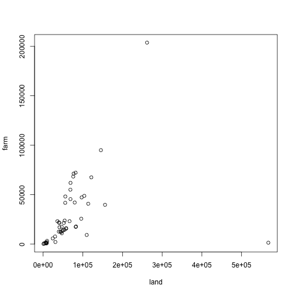

```r
plot(farm ~ land, data = farmland)
```

[figure not shown]

```r
curve(rho(x, k = 19000), xlim = c(-10, 10), col = "blue", add = "TRUE")
```

It is less influenced because we are using MMSE.

## Q3 : Exponential smoothing

Consider the `nhtemp` dataset which holds yearly average measurements of temperature for New Hampshire, from 1912 to 1971

```r
require(datasets)
str(nhtemp)
```

```
##  Time-Series [1:60] from 1912 to 1971: 49.9 52.3 49.4 51.1 49.4 47.9 49.8 50.9 49.3 51.9 ...
```

We want to fit an exponential smoothing model to this data, in which

\[ \hat{Y}_i = \beta Y_{i-1} + (1-\beta) \hat{Y}_{i-1} \]

Set \( \hat{Y}_2 = \hat{Y}_1 = Y_1 \) for simplicity sake. We will choose the parameter estimate \( \hat{\beta} \) that minimizes the mean forecast error

\[ FE(\beta) = \frac{1}{n} \sum_{i=2}^n \left( Y_i - \hat{Y}_i \right)^2 \]

The derivatives of this function are rather complicated (note \( \hat{Y}_i \) is a function of \( \beta \)), so let's use a derivative-free method based on the function `optimize()`.

a. Using `optimize()` on the interval \( [0,1] \), find the value of \( \beta \) that produces the minimum forecast error. Set \( \hat{Y}_2 = \hat{Y}_1 = Y_1 \) for simplicity.

```r
require(datasets)
data(nhtemp)
str(nhtemp)
```

```
##  Time-Series [1:60] from 1912 to 1971: 49.9 52.3 49.4 51.1 49.4 47.9 49.8 50.9 49.3 51.9 ...
```

```r
y.hat <- function(beta, y = nhtemp) {
    y.hat = numeric(length(y))
    y.hat[1] = y[1]
    y.hat[2] = y[2]
    for (i in 3:length(y)) {
        y.hat[i] = beta * y[i - 1] + (1 - beta) * y.hat[i - 1]
    }
    return(y.hat)

}
mona.function <- function(beta, y = nhtemp) {
    n <- length(y)
    y.hat.value <- y.hat(beta, nhtemp)
    sq.sum = 0
    for (i in 2:n) {
        sq.sum = sq.sum + (y[i] - y.hat.value[i])^2

    }
    return(sq.sum/n)
}

opt.result = optimize(mona.function, c(0, 1), maximum = FALSE)
(y.hat.value = y.hat(opt.result$minimum, nhtemp))
```

```
##  [1] 49.90 52.30 52.30 51.30 51.23 50.59 49.66 49.71 50.12 49.84 50.55
## [12] 50.64 50.28 49.94 50.17 49.56 49.95 50.28 50.39 50.78 51.48 51.59
## [23] 51.42 50.86 50.63 50.55 50.91 51.22 51.11 50.31 50.79 50.86 50.77
## [34] 51.09 51.23 51.53 51.45 51.30 52.23 51.94 52.21 52.52 53.24 52.81
## [45] 52.53 51.96 52.18 51.50 51.88 51.78 51.82 51.36 51.20 51.38 51.38
## [56] 51.49 51.25 51.48 51.59 51.70
```

b. Plot the yearly average measurements of temperature for New Hampshire, from 1912 to 1971, and overlay an exponential smoothing of it using `lines()` (use a different color).

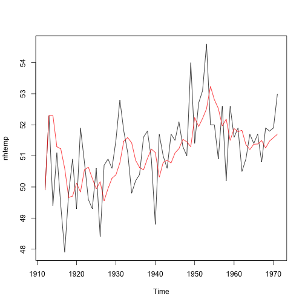

```r
plot(nhtemp)
lines(ts(y.hat.value, start = start(nhtemp)[1], end = end(nhtemp)[1]), col = "red")
```

c. Reproduce the previous plot, but include some other levels of smoothing, say \( \beta=0.1 \) and \( \beta=0.9 \). Use different colors and include a legend.

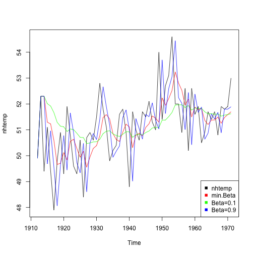

```r
plot(nhtemp)
lines(ts(y.hat.value, start = start(nhtemp)[1], end = end(nhtemp)[1]), col = "red")

beta = 0.1
y.hat.value <- y.hat(beta, nhtemp)
lines(ts(y.hat.value, start = start(nhtemp)[1], end = end(nhtemp)[1]), col = "green")

beta = 0.9
y.hat.value <- y.hat(beta, nhtemp)
lines(ts(y.hat.value, start = start(nhtemp)[1], end = end(nhtemp)[1]), col = "blue")

legend("bottomright", c("nhtemp", "min.Beta", "Beta=0.1", "Beta=0.9"), col = c("black",
    "red", "green", "blue"), cex = 1, pch = 15)
```